# netflixdata

```python
!pip install pandas matplotlib numpy
```

This loads pandas library and give ashort name as pd

```python
import pandas as pd
df= pd.read_csv("netflixdata.csv")
df.head() # this is to show the first rows
```

|  | Title | Genre | Year | IMDb Rating | Viewership (Billions) | Episode Duration |
| --- | --- | --- | --- | --- | --- | --- |
| 0 | Stranger Things | Sci-Fi | 2016 | 8.7 | 1.0 | 50 min |
| 1 | Wednesday | Mystery | 2022 | 8.1 | 1.7 | 50 min |
| 2 | Squid Game | Thriller | 2021 | 8.0 | 1.6 | 55 min |
| 3 | Bridgerton | Romance | 2020 | 7.3 | 0.9 | 60 min |
| 4 | Money Heist (La Casa de Papel) | Crime | 2017 | 8.2 | 1.0 | 50 min |

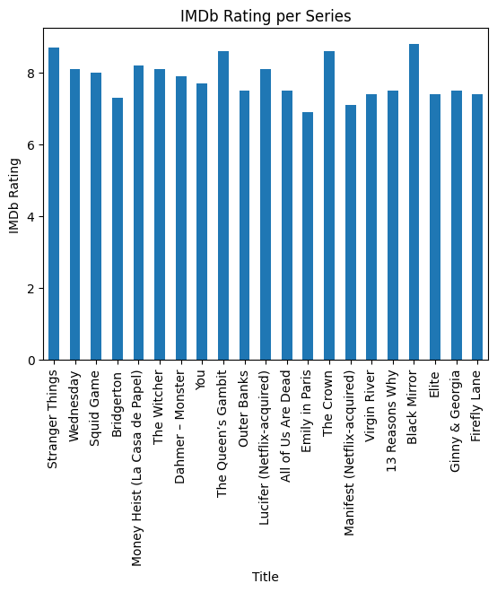

```python
df.plot(kind="bar", x="Title", y="IMDb Rating", legend=False)
plt.ylabel("IMDb Rating")
plt.title("IMDb Rating per Series")
plt.show()
```

This chart shows that most Netflix series in the dataset have IMDb ratings between 7.0 and 8.5. "Black Mirror" and "Stranger Things" stand out as the highest-rated shows, while "Emily in Paris" has the lowest rating among them.

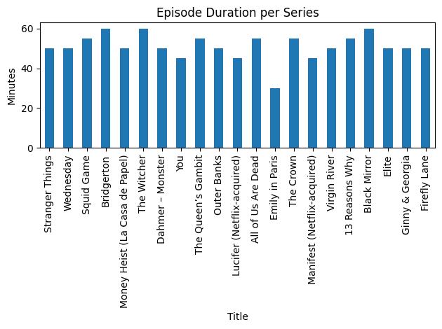

```python
df.plot(kind="bar", x="Title", y="Episode Duration", legend=False)
plt.ylabel("Minutes")
plt.title("Episode Duration per Series")
plt.tight_layout()
plt.show()
```

This column chart shows that episode duration is quite consistent for most series, typically between 45 and 60 minutes. "Emily in Paris" has shorter episodes (around 30 minutes), in comparison to "Black Mirror" and "The Witcher" whose episodes tend to be the longest (around 60 minutes).

[figure not shown]

```python
avg_ratings = df.groupby("Genre")["IMDb Rating"].mean().sort_values(ascending=False)

# Pie chart
plt.figure(figsize=(8, 8))
avg_ratings.plot(kind="pie", autopct='%1.1f%%', legend=False,
ylabel=""   # removes the default y-label
)
# Title
plt.title("Average IMDb Rating per Genre")
plt.show()
```

This pie chart highlights how different genres compare in ratings.Genres like Drama, Historical Drama, and Sci-Fi have slightly higher average ratings, suggesting strong audience engagement. Meanwhile, genres such as Romantic Comedy and Romance score lower on the average.

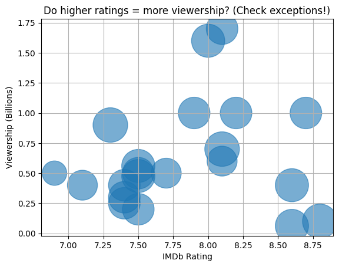

```python
# Scatter plot
plt.scatter( df["IMDb Rating"], df["Viewership (Billions)"], s=df["Episode Duration"]*30, alpha=0.6)
plt.title("Do higher ratings = more viewership? (Check exceptions!)")
plt.xlabel("IMDb Rating")
plt.ylabel("Viewership (Billions)")
plt.grid(True)
plt.show()
```

The scatter plot reveals that higher ratings do not always equal higher viewership. Series with strong ratings don’t necessarily always reach a large audience, showing that factors beyond quality affect viewership.

```
Minimum duration: 30 Q1: 50.0
```

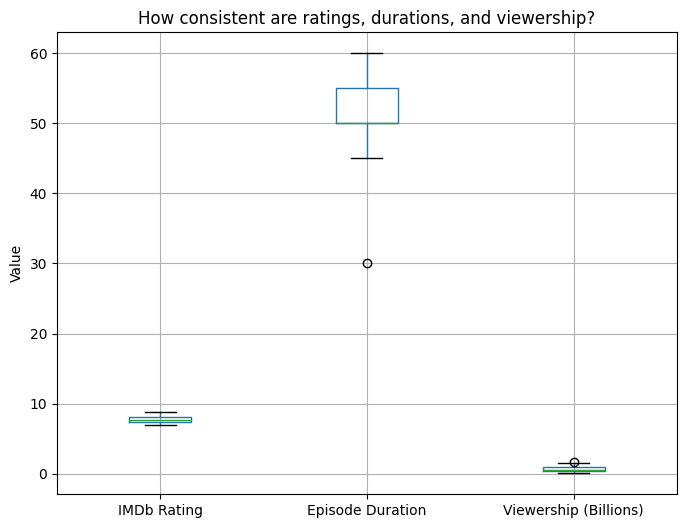

```python
# Calculate quartiles and extremes for Episode Duration
hours_min = df["Episode Duration"].min()
hours_q1 = df["Episode Duration"].quantile(0.25)
print("Minimum duration:", hours_min, "Q1:", hours_q1)

# Box plot of numeric columns
plt.figure(figsize=(8,6))
df[["IMDb Rating", "Episode Duration", "Viewership (Billions)"]].boxplot()
plt.title("How consistent are ratings, durations, and viewership?")
plt.ylabel("Value")
plt.show()
```